# Advanced Classification - Part 6

One should look for what is and not what he thinks should be. (Albert Einstein)

# Module completion checklist

| Objective | Complete |
| --- | --- |
| Summarize the key differences between support vector classifier and support vector machine |  |
| Build a support vector machine model to classify the Costa Rica dataset |  |
| Optimize the support vector machine model using grid search |  |

# Loading packages

- Let’s load the packages we will be using
- These packages are used for classification in SVM

```python
import os
import pickle
import numpy as np
import pandas as pd
import matplotlib.pyplot as plt
from pathlib import Path
from sklearn.model_selection import train_test_split
from sklearn.svm import SVC
from sklearn import metrics
from sklearn.model_selection import GridSearchCV
```

# Goal

- We already used our `Costa Rican` dataset and classified the poverty levels of the individuals
- We are going to do the same today
- We will determine whether a person is classified as **poor or not** based on the information we have about that person’s living conditions and educational qualifications
- We will build 2 models today
  - Support vector machine, and
  - Optimized support vector machine using grid search

# Classification with non-linear boundary

- What if our data cannot be classified using linear boundary?
- SVCs can be useless in a highly non-linear class boundary
- In that case, we can introduce a **classifier with a non-linear decision boundary** or non-linear hyperplane
- Support vector classifiers with a non-linear decision boundary are called support vector machines (SVM)

# Transforming the features

- The idea is to transform the `p` features into a higher dimensional space
- For example, if we are transforming in quadratic space, we convert `p` features to a `2p` feature dimension

$$\text{Consider p features } \\
x_1, x_2,.....x_n \\
\text{They are transformed to 2p features} \\ \\
x_1, x_1^2, ...x_n, x_n^2$$

# Support vector machine

- The decision boundary is non-linear in p-dimensional space, but it is linear in the new transformed dimensional space
- This is called the kernel approach and the classifier is called the support vector machines (SVM)
- It can use **quadratic, cubic, or even higher order polynomial functions**
- The problem with it is that we start to accumulate more features since they are transformed and computation becomes unmanageable quickly

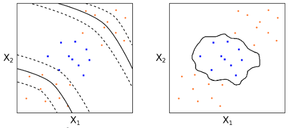

# Decision boundary

- The decision boundary is non-linear in p-dimensional space, but it is linear in the new transformed dimensional space

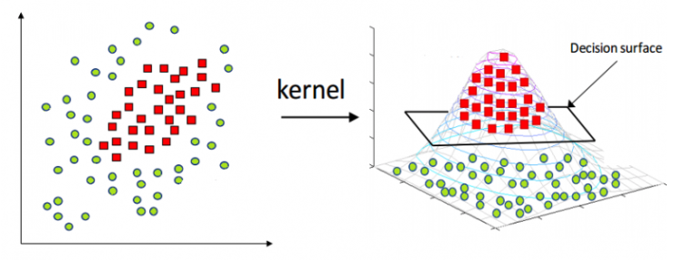

- We have different kernels (non linear boundary conditions) to do it
  - radial
  - polynomial
  - quadratic
  - cubic

# Kernel: radial basis function

- Today we will use radial basis function (RBF) kernel for our data
- RBF kernel is the general purpose kernel used when there is no prior knowledge about the data
- Consider there are two observations x and x’ - the RBF kernel is defined by the mathematical equation

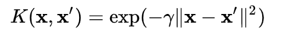

# Kernel: gamma value

- `Gamma` is the value which controls the shape of the kernel
- The default value of `gamma` is `scale` which means it uses `1 / (n_features * variance of X)`
- If `auto`, uses `1 / n_features`
- Alternatively one can pass float values to `gamma`
- We will use an arbitrary value of `0.011` for `gamma`

# Module completion checklist

| Objective | Complete |
| --- | --- |
| Summarize the key differences between support vector classifier and support vector machine | **✔** |
| Build a support vector machine model to classify the Costa Rica dataset |  |
| Optimize the support vector machine model using grid search |  |

# Review data cleaning steps

- **Today, we will be loading the cleaned dataset we used earlier**
- To recap, the steps to get to this cleaned dataset were:
  - Remove household ID and individual ID
  - Remove variables with over 50% NAs
  - Transformed target variable to binary
  - Remove highly correlated variables

# Directory settings

- In order to maximize the efficiency of your workflow, you should encode your directory structure into `variables`
- We will use the `pathlib` library
- Let the `main_dir` be the variable corresponding to your `course` folder
- Let `data_dir` be the variable corresponding to your `data` folder

```python
# Set 'main_dir' to location of the project folder
home_dir = Path(".").resolve()
main_dir = home_dir.parent.parent
print(main_dir)
```

```python
data_dir = str(main_dir) + "/data"
print(data_dir)
```

# Load the cleaned dataset

- Let’s load the pickled dataset, `costa_clean`
- Save it as `costa_clean`

```python
costa_clean = pickle.load(open((data_dir + "/costa_clean.sav"),"rb"))
```

```python
# Print the head.
print(costa_clean.head())
```

```
   rooms  tablet  males_under_12  ...  rural_zone  age  Target
0      3       0               0  ...           0   43    True
1      4       1               0  ...           0   67    True
2      8       0               0  ...           0   92    True
3      5       1               0  ...           0   17    True
4      5       1               0  ...           0   37    True

[5 rows x 81 columns]
```

# Print info on data

- Let’s view the column names

```python
# Print the columns.
costa_clean.columns
```

```
Index(['rooms', 'tablet', 'males_under_12', 'males_over_12', 'males_tot',
       'females_under_12', 'females_over_12', 'females_tot', 'ppl_under_12',
       'ppl_over_12', 'ppl_total', 'years_of_schooling', 'wall_block_brick',
       'wall_socket', 'wall_prefab_cement', 'wall_wood', 'floor_mos_cer_terr',
       'floor_cement', 'floor_wood', 'ceiling', 'electric_public',
       'electric_coop', 'toilet_sewer', 'toilet_septic', 'cookenergy_elec',
       'cookenergy_gas', 'trash_truck', 'trash_burn', 'wall_bad', 'wall_reg',
       'wall_good', 'roof_bad', 'roof_reg', 'roof_good', 'floor_bad',
       'floor_reg', 'floor_good', 'disabled_ppl', 'male', 'female', 'under10',
       'free', 'married', 'separated', 'single', 'hh_head', 'hh_spouse',
       'hh_child', 'num_child', 'num_adults', 'num_65plus', 'num_hh_total',
       'dependency_rate', 'male_hh_head_educ', 'female_hh_head_educ',
       'meaneduc', 'educ_none', 'educ_primary_inc', 'educ_primary',
       'educ_secondary_inc', 'educ_secondary', 'educ_undergrad', 'bedrooms',
       'ppl_per_room', 'house_owned_full', 'house_owned_paying',
       'house_rented', 'house_other', 'computer', 'television',
       'num_mobilephones', 'region_central', 'region_Chorotega',
       'region_pacifico', 'region_brunca', 'region_antlantica',
       'region_huetar', 'urban_zone', 'rural_zone', 'age', 'Target'],
      dtype='object')
```

# Split into training and test sets

```python
# Select the predictors and target.
X = costa_clean.drop(['Target'], axis = 1)
y = np.array(costa_clean['Target'])

# Set the seed to 1.
np.random.seed(1)

# Split into training and test sets with 70% train and 30% test.
X_train, X_test, y_train, y_test = train_test_split(X, y, test_size = 0.3)
```

# Build a SVM model

```python
# Build the SVM model.
# Note here that the kernel rbf means radial kernel.
sv_machine = SVC(kernel = 'rbf',
                  gamma = 0.011,
                  probability = True)
sv_machine.fit(X_train, y_train)
```

```
SVC(gamma=0.011, probability=True)
```

# Predict on the test dataset

```python
# Predict on the test dataset.
svm_y_predict = sv_machine.predict(X_test)
svm_y_predict[0:5]

# Predict on test, but instead of labels
# we will get probabilities for class 0 and 1.
```

```
array([ True,  True,  True,  True,  True])
```

```python
svm_y_predict_prob = sv_machine.predict_proba(X_test)
print(svm_y_predict_prob[5:])
```

```
[[0.40850243 0.59149757]
 [0.10654403 0.89345597]
 [0.1395987  0.8604013 ]
 ...
 [0.13136736 0.86863264]
 [0.83573684 0.16426316]
 [0.86367169 0.13632831]]
```

# Recap: score evaluation function

- Earlier, we used a function to wrap all performance score calculations into one block of code which can be called repeatedly
- We will use this function to evaluate our SVM models today

```python
def get_performance_scores(y_test, y_predict, y_predict_prob, eps=1e-15, beta=0.5):
    from sklearn import metrics
    # Scores keys.
    metric_keys = ["accuracy", "precision", "recall", "f1", "fbeta", "log_loss", "AUC"]
    # Score values.
    metric_values = [None]*len(metric_keys)
    metric_values[0] = metrics.accuracy_score(y_test, y_predict)
    metric_values[1] = metrics.precision_score(y_test, y_predict)
    metric_values[2] = metrics.recall_score(y_test, y_predict)
    metric_values[3] = metrics.f1_score(y_test, y_predict)
    metric_values[4] = metrics.fbeta_score(y_test, y_predict, beta=beta)
    metric_values[5] = metrics.log_loss(y_test, y_predict_prob[:, 1], eps=eps)
    metric_values[6] = metrics.roc_auc_score(y_test, y_predict_prob[:, 1])
    perf_metrics = dict(zip(metric_keys, metric_values))
    return(perf_metrics)
```

# Predict on the test dataset

```python
svm_scores = get_performance_scores(y_test, svm_y_predict, svm_y_predict_prob)
print(svm_scores)
```

```
{'accuracy': 0.7904463040446305, 'precision': 0.8032209360845496, 'recall': 0.8837209302325582, 'f1': 0.8415502240970207, 'fbeta': 0.8181258970678695, 'log_loss': 0.4574972925256918, 'AUC': 0.855928553701514}
```

# Precision vs recall curve: the tradeoff

- Plot precision vs recall curve for the SVM model

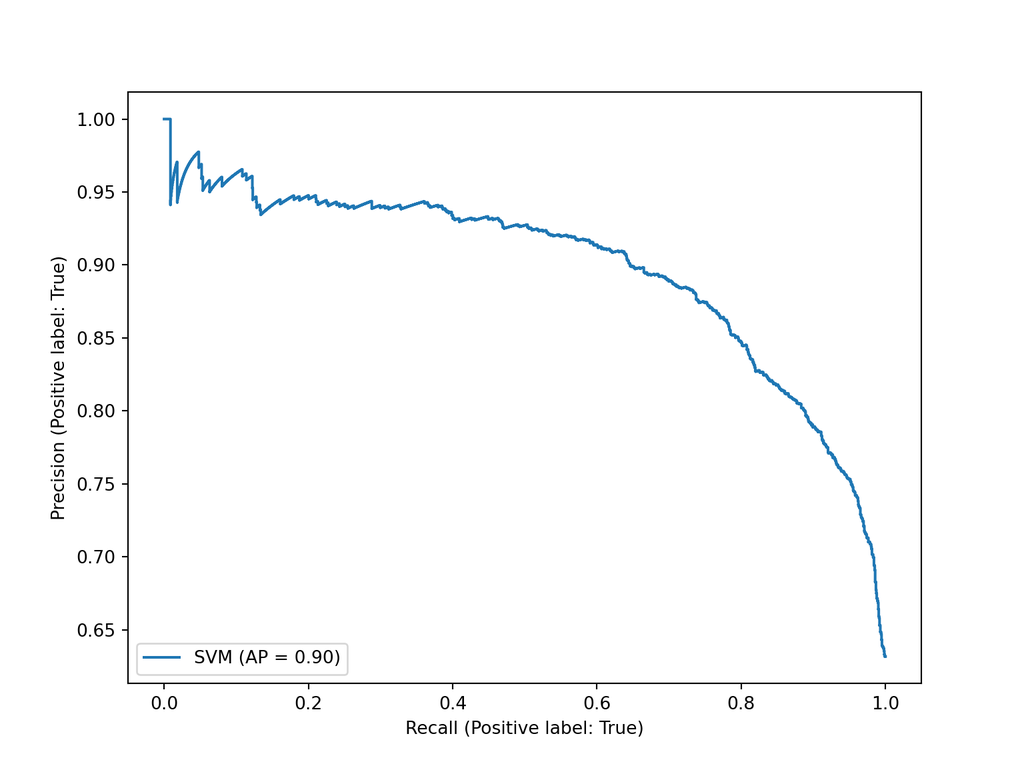

```python
ax = plt.gca() #<- create a new axis object
svm_prec_recall = metrics.plot_precision_recall_curve(sv_machine,
                                 X_test,
                                 y_test,
                                 ax = ax,
                                 name = "SVM")

plt.show()
```

# ROC curve: the tradeoff

- Plot ROC curve for the SVM model

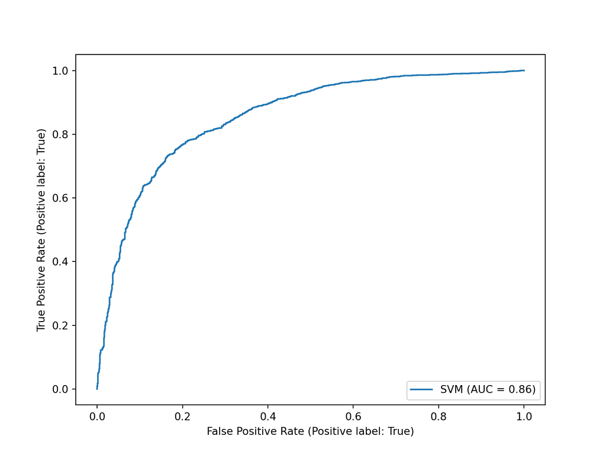

```python
ax = plt.gca()
svm_roc = metrics.plot_roc_curve(sv_machine,
                       X_test,
                       y_test,
                       name = "SVM",
                       ax = ax)

plt.show()
```

# Save final metrics of SVM

- **Let’s save our svm score in our `metrics_svm` dataset**
- We first have to load our `metrics_svm` dataframe which we created previously

```python
metrics_svm = pickle.load(open((data_dir + "/metrics_svm.sav"),"rb"))
```

# Save final metrics of SVM

```python
# Add the model to our dataframe.
metrics_svm.update({"SVM": svm_scores})
print(metrics_svm)
```

```
{'RF': {'accuracy': 0.9483960948396095, 'precision': 0.9447424892703863, 'recall': 0.9750830564784053, 'f1': 0.9596730245231607, 'fbeta': 0.9506586050529044, 'log_loss': 0.21947942349408847, 'AUC': 0.986855647527701}, 'Optimized RF': {'accuracy': 0.9483960948396095, 'precision': 0.9400212314225053, 'recall': 0.9806201550387597, 'f1': 0.9598915989159891, 'fbeta': 0.9478698351530723, 'log_loss': 0.21667604220201855, 'AUC': 0.9876901226920936}, 'GBM': {'accuracy': 0.8291492329149233, 'precision': 0.8374358974358974, 'recall': 0.9042081949058693, 'f1': 0.869542066027689, 'fbeta': 0.8499895898396836, 'log_loss': 0.39102395649143923, 'AUC': 0.902052011186816}, 'Optimized GBM': {'accuracy': 0.9605997210599722, 'precision': 0.9684560044272275, 'recall': 0.9689922480620154, 'f1': 0.9687240520343205, 'fbeta': 0.9685632056674784, 'log_loss': 0.5487445996283076, 'AUC': 0.9918971705530634}, 'SVC': {'accuracy': 0.7890516039051604, 'precision': 0.8081067213955875, 'recall': 0.872093023255814, 'f1': 0.8388814913448736, 'fbeta': 0.8201416371589252, 'log_loss': 0.45830503084971225, 'AUC': 0.85334770267762}, 'SVM': {'accuracy': 0.7904463040446305, 'precision': 0.8032209360845496, 'recall': 0.8837209302325582, 'f1': 0.8415502240970207, 'fbeta': 0.8181258970678695, 'log_loss': 0.4574972925256918, 'AUC': 0.855928553701514}}
```

- The performance of SVM increased slightly when compared to SVC mostly because our decision boundary is non-linear

# Knowledge check 1

# Exercise 1

# Module completion checklist

| Objective | Complete |
| --- | --- |
| Summarize the key differences between support vector classifier and support vector machine | **✔** |
| Build a support vector machine model to classify the Costa Rica dataset | **✔** |
| Optimize the support vector machine model using grid search |  |

# Optimize the SVM model with grid search

- Until now, we have used arbitrary values for $C$ and $\gamma$
- **Grid search** gives a range of n values to a particular parameter in the model and lets the model choose the best tuning parameter from the best model
- Here, we give the range of values to both $C$ and $\gamma$ parameters to chose the best tuning parameter and do 5 fold cross-validation

# Grid search and cv on SVM model

```python
# Set the parameters by cross-validation.
tuned_parameters = [{'kernel': ['rbf'], 'gamma': [1e-3, 1e-4],
                     'C': [1, 10, 100, 1000]}]

# Fit the tuned parameters for grid search with 5 fold cross-validation to SVM.
svm_cv = GridSearchCV(SVC(), tuned_parameters, cv = 5)
svm_cv.fit(X_train, y_train)
```

```
GridSearchCV(cv=5, estimator=SVC(),
             param_grid=[{'C': [1, 10, 100, 1000], 'gamma': [0.001, 0.0001],
                          'kernel': ['rbf']}])
```

# Find best parameters

```python
# Find the best tuned parameters.
print(svm_cv.best_params_)
```

```
{'C': 1000, 'gamma': 0.001, 'kernel': 'rbf'}
```

```python
# Extract the best hyperparameters.
optimized_c = svm_cv.best_params_['C']
optimized_gamma = svm_cv.best_params_['gamma']
optimized_kernel = svm_cv.best_params_['kernel']
```

- Thus, we find that the optimum `C` value was very different from our default value of `1`

# Fit the best parameters to build the optimized model

```python
# Run the model with optimized hyperparameters.
sv_cv_optimized = SVC(kernel = optimized_kernel,
                      gamma = optimized_gamma,
                      C = optimized_c,
                      probability = True)

sv_cv_optimized.fit(X_train, y_train)
```

```
SVC(C=1000, gamma=0.001, probability=True)
```

# Predict on the test dataset

```python
# Predict on the test dataset.
opt_svm_y_predict = sv_cv_optimized.predict(X_test)
opt_svm_y_predict[0:5]

# Predict on test, but instead of labels
# we will get probabilities for class 0 and 1.
```

```
array([ True,  True,  True,  True,  True])
```

```python
opt_svm_y_predict_prob = sv_cv_optimized.predict_proba(X_test)
print(opt_svm_y_predict_prob[5:])
```

```
[[0.75667416 0.24332584]
 [0.00745365 0.99254635]
 [0.01396175 0.98603825]
 ...
 [0.12930068 0.87069932]
 [0.51275975 0.48724025]
 [0.85417574 0.14582426]]
```

# Predict on the test dataset

```python
opt_svm_scores = get_performance_scores(y_test, opt_svm_y_predict, opt_svm_y_predict_prob)
print(opt_svm_scores)
```

```
{'accuracy': 0.8315899581589958, 'precision': 0.8573743922204214, 'recall': 0.8787375415282392, 'f1': 0.8679245283018868, 'fbeta': 0.8615635179153094, 'log_loss': 0.3939702321910344, 'AUC': 0.8962732511214971}
```

- As we can see, our optimized SVM model performed much better than the original SVM model

# Precision vs recall curve: the tradeoff

```python
ax = plt.gca() #<- create a new axis object
opt_svm_prec_recall = metrics.plot_precision_recall_curve(sv_cv_optimized,
                                 X_test,
                                 y_test,
                                 ax = ax,
                                 name = "Optimized SVM")

svm_prec_recall.plot(ax = ax, name = "SVM") #<- add rf plot
plt.show()
```

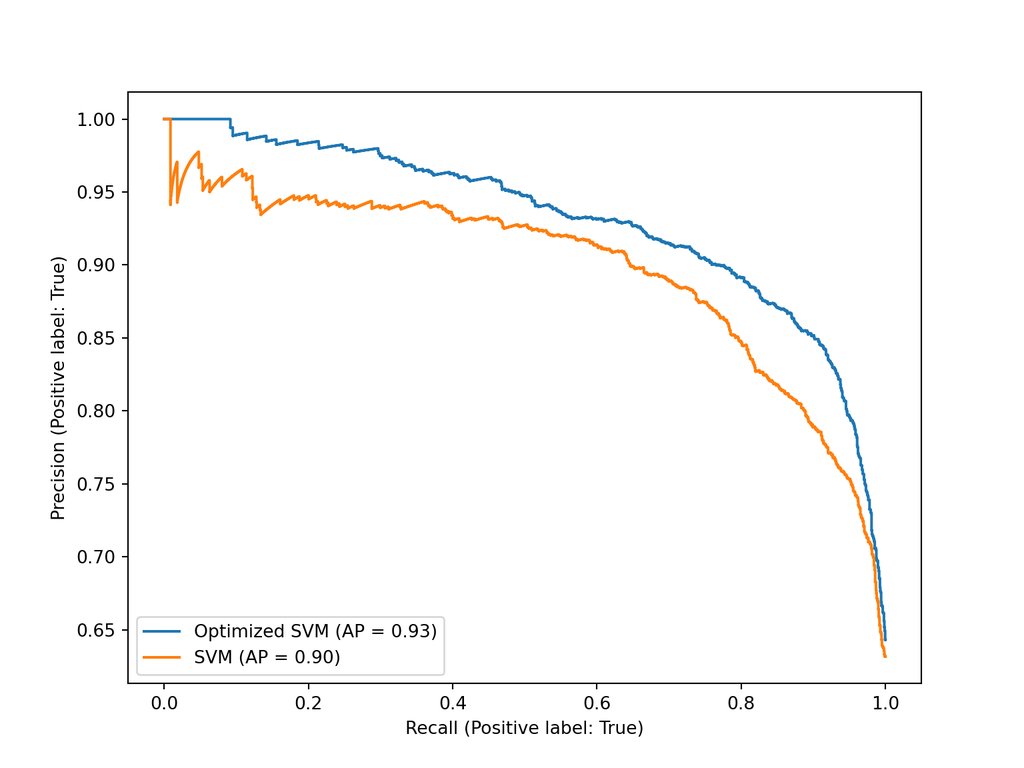

# ROC curve: the tradeoff

```python
ax = plt.gca()
opt_svm_roc = metrics.plot_roc_curve(sv_cv_optimized,
                       X_test,
                       y_test,
                       name = "Optimized SVM",
                       ax = ax)

svm_roc.plot(ax = ax, name = "SVM")
plt.show()
```

- The AUC for this curve is about 90%, which is good!
- As we can see, our optimized SVM model has a higher AUC than the original SVM model

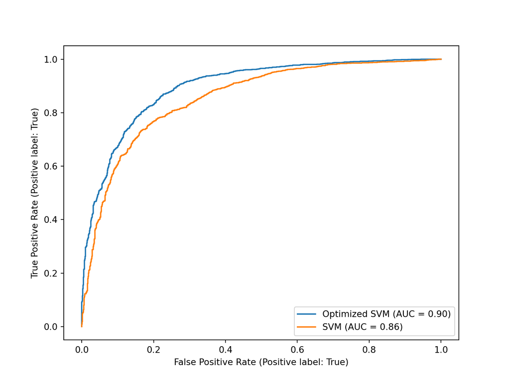

# Save final metrics of SVM

```python
# Add the model to our dataframe.
metrics_svm.update({"Optimized SVM": opt_svm_scores})
print(metrics_svm)
```

```
{'RF': {'accuracy': 0.9483960948396095, 'precision': 0.9447424892703863, 'recall': 0.9750830564784053, 'f1': 0.9596730245231607, 'fbeta': 0.9506586050529044, 'log_loss': 0.21947942349408847, 'AUC': 0.986855647527701}, 'Optimized RF': {'accuracy': 0.9483960948396095, 'precision': 0.9400212314225053, 'recall': 0.9806201550387597, 'f1': 0.9598915989159891, 'fbeta': 0.9478698351530723, 'log_loss': 0.21667604220201855, 'AUC': 0.9876901226920936}, 'GBM': {'accuracy': 0.8291492329149233, 'precision': 0.8374358974358974, 'recall': 0.9042081949058693, 'f1': 0.869542066027689, 'fbeta': 0.8499895898396836, 'log_loss': 0.39102395649143923, 'AUC': 0.902052011186816}, 'Optimized GBM': {'accuracy': 0.9605997210599722, 'precision': 0.9684560044272275, 'recall': 0.9689922480620154, 'f1': 0.9687240520343205, 'fbeta': 0.9685632056674784, 'log_loss': 0.5487445996283076, 'AUC': 0.9918971705530634}, 'SVC': {'accuracy': 0.7890516039051604, 'precision': 0.8081067213955875, 'recall': 0.872093023255814, 'f1': 0.8388814913448736, 'fbeta': 0.8201416371589252, 'log_loss': 0.45830503084971225, 'AUC': 0.85334770267762}, 'SVM': {'accuracy': 0.7904463040446305, 'precision': 0.8032209360845496, 'recall': 0.8837209302325582, 'f1': 0.8415502240970207, 'fbeta': 0.8181258970678695, 'log_loss': 0.4574972925256918, 'AUC': 0.855928553701514}, 'Optimized SVM': {'accuracy': 0.8315899581589958, 'precision': 0.8573743922204214, 'recall': 0.8787375415282392, 'f1': 0.8679245283018868, 'fbeta': 0.8615635179153094, 'log_loss': 0.3939702321910344, 'AUC': 0.8962732511214971}}
```

- The accuracy of our optimized SVM has increased here since we found the optimal tuning parameters and ran it with a cross-validation

# Create comparison plot using function

- Use the previously created `compare_metrics` function to create the comparison plot

```python
def compare_metrics(metrics_dict, color_list = None):
    metrics_df = pd.DataFrame(metrics_dict)
    metrics_df["metric"] = metrics_df.index
    metrics_df = metrics_df.reset_index(drop = True)
    metrics_long = pd.melt(metrics_df, id_vars = "metric", var_name = "model",
                           value_vars = list(metrics_dict.keys()))
    if color_list is None:
        cmap = plt.rcParams['axes.prop_cycle'].by_key()['color']
        colors = cmap[:len(metrics_dict.keys())]
    else:
        colors = color_list
    fig, axes = plt.subplots(2, 3, figsize = (12, 6))
    for (metric, group), ax in zip(metrics_long.groupby("metric"), axes.flatten()):
        group.plot(x = 'model', y = 'value', kind = 'bar',color = colors,ax = ax,
                   title = metric,legend = None,sharex = True)
        ax.xaxis.set_tick_params(rotation = 45,labelsize=7)
    plt.tight_layout(0.5)
    return((fig, axes))
```

# Create comparison plot using function

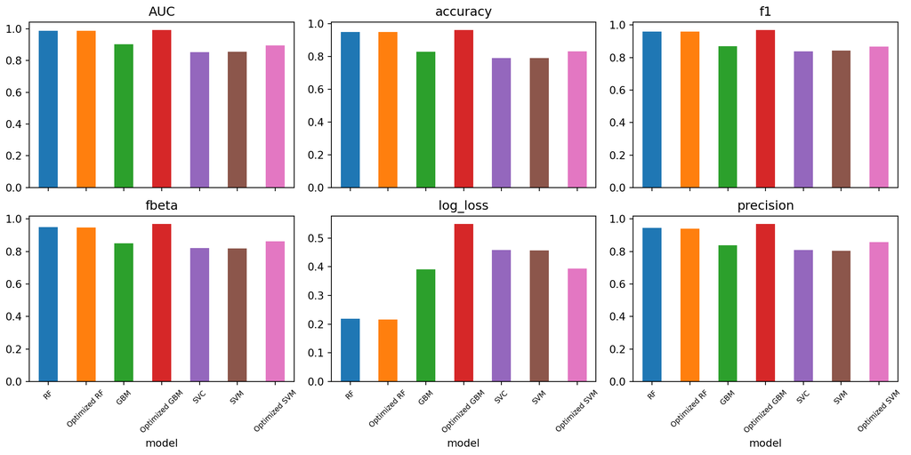

```python
fig, axes = compare_metrics(metrics_svm)
plt.show()
```

# SVM performance

- Although ensemble classifiers outperformed SVM, it would still probably perform better than most of the single classifier models
- This is because we have a lot of categorical variables and SVM models them better than the other models
- We also noted that our model performance improved after optimization
- We could increase our grid search range to improve the performance further, however this would come at the cost of computational complexity

# Advantages and disadvantages of SVM

- Advantages
  - It is an effective classifier for **high dimensional data**
  - Memory efficient, since only the support vectors are needed to be stored in memory for making the classification decision
  - Versatile by allowing **different boundary conditions**
- Disadvantages
  - It is **non-probabilistic**, so there is no probabilistic interpretation for group membership
  - When `p > n`, i.e. when number of predictors exceeds the number of observations, SVM performs poorly

# Knowledge check 2

# Exercise 2

# Module completion checklist

| Objective | Complete |
| --- | --- |
| Summarize the key differences between support vector classifier and support vector machine | **✔** |
| Build a support vector machine model to classify the Costa Rica dataset | **✔** |
| Optimize the support vector machine model using grid search | **✔** |

# Summary

- Today we learned:
  - concepts of hyperplanes and Support Vector Machines
  - how SVMs can be used to create non-linear classifications
- There are many data science areas you can explore next like recommender systems, neural networks, deep learning, text mining, and others!

# Congratulations on completing this module!